# REIMS sample analysis

Nathan Alexander

2024-06-03

# Set up

### Set up `MPlusAutomation`

```r
install.packages("devtools")
library(devtools)

install_github("michaelhallquist/MplusAutomation")
```

### Load packages

```
## Version:  1.2
## We work hard to write this free software. Please help us get credit by citing:
##
## Hallquist, M. N. & Wiley, J. F. (2018). MplusAutomation: An R Package for Facilitating Large-Scale Latent Variable Analyses in Mplus. Structural Equation Modeling, 25, 621-638. doi: 10.1080/10705511.2017.1402334.
##
## -- see citation("MplusAutomation").
```

```
## here() starts at /Users/nathanalexander/Dropbox/Projects/immerse
##
## here() starts at /Users/nathanalexander/Dropbox/Projects/immerse/reims
```

### Data

```r
# set data
reims <- read_csv(here("data", "reims_clean.csv"))
```

```
## ──────────────────────────────────────────────────────── Delimiter: "," dbl
## (57): groupflag, age, sex, race, mathperson1, mathperson2, mathperson3, ...
```

```r
# inspect data
reims
```

```
## # A tibble: 103 × 57
##    groupflag   age   sex  race mathperson1 mathperson2 mathperson3 mathperson4
##        <dbl> <dbl> <dbl> <dbl>       <dbl>       <dbl>       <dbl>       <dbl>
##  1         1    18     2     6           0           0           0           0
##  2         1    22     2     1           0           0           0           0
##  3         1    20     1     7           1           1           1           1
##  4         1    20     1     3           1           1           1           1
##  5         1    18     1     4           0           0           0           1
##  6         1    18     2     6           0           0           0           0
##  7         1    19     1     6           0           0           0           0
##  8         1    23     2     4           0           0           0           0
##  9         1    37     2     3           0           0           0           0
## 10         1    27     2     6           0           0           0           0
## # ℹ 93 more rows
## # ℹ 49 more variables: dislikemathclass <dbl>, pursuestem <dbl>,
## #   boysbetter <dbl>, learnrace <dbl>, racegroups <dbl>, knowrace <dbl>,
## #   connectrace1 <dbl>, affectrace <dbl>, proudrace <dbl>, mixrace <dbl>,
## #   unclearrace <dbl>, connectrace2 <dbl>, dontknowrace <dbl>,
## #   belongrace <dbl>, understandrace <dbl>, talkrace <dbl>, priderace <dbl>,
## #   avoidrace <dbl>, practicerace <dbl>, playotherrace <dbl>, …
```

```r
summary(reims)
```

```
##    groupflag           age             sex            race
##  Min.   :0.0000   Min.   :14.00   Min.   :1.00   Min.   :1.00
##  1st Qu.:1.0000   1st Qu.:18.00   1st Qu.:1.00   1st Qu.:3.00
##  Median :1.0000   Median :20.00   Median :2.00   Median :4.00
##  Mean   :0.8835   Mean   :20.82   Mean   :1.65   Mean   :3.99
##  3rd Qu.:1.0000   3rd Qu.:21.00   3rd Qu.:2.00   3rd Qu.:6.00
##  Max.   :1.0000   Max.   :47.00   Max.   :3.00   Max.   :7.00
##   mathperson1      mathperson2      mathperson3      mathperson4
##  Min.   :0.0000   Min.   :0.0000   Min.   :0.0000   Min.   :0.0000
##  1st Qu.:0.0000   1st Qu.:0.0000   1st Qu.:0.0000   1st Qu.:0.0000
##  Median :1.0000   Median :1.0000   Median :1.0000   Median :1.0000
##  Mean   :0.5922   Mean   :0.5631   Mean   :0.5146   Mean   :0.5146
##  3rd Qu.:1.0000   3rd Qu.:1.0000   3rd Qu.:1.0000   3rd Qu.:1.0000
##  Max.   :1.0000   Max.   :1.0000   Max.   :1.0000   Max.   :1.0000
##  dislikemathclass   pursuestem       boysbetter        learnrace
##  Min.   :0.0000   Min.   :0.0000   Min.   :0.00000   Min.   :0.0000
##  1st Qu.:0.0000   1st Qu.:0.0000   1st Qu.:0.00000   1st Qu.:0.0000
##  Median :0.0000   Median :1.0000   Median :0.00000   Median :0.0000
##  Mean   :0.2524   Mean   :0.5534   Mean   :0.07767   Mean   :0.4078
##  3rd Qu.:0.5000   3rd Qu.:1.0000   3rd Qu.:0.00000   3rd Qu.:1.0000
##  Max.   :1.0000   Max.   :1.0000   Max.   :1.00000   Max.   :1.0000
##    racegroups        knowrace       connectrace1      affectrace
##  Min.   :0.0000   Min.   :0.0000   Min.   :0.0000   Min.   :0.0000
##  1st Qu.:0.0000   1st Qu.:0.0000   1st Qu.:1.0000   1st Qu.:0.0000
##  Median :0.0000   Median :1.0000   Median :1.0000   Median :0.0000
##  Mean   :0.3301   Mean   :0.6311   Mean   :0.8641   Mean   :0.4563
##  3rd Qu.:1.0000   3rd Qu.:1.0000   3rd Qu.:1.0000   3rd Qu.:1.0000
##  Max.   :1.0000   Max.   :1.0000   Max.   :1.0000   Max.   :1.0000
##    proudrace         mixrace         unclearrace      connectrace2
##  Min.   :0.0000   Min.   :0.00000   Min.   :0.0000   Min.   :0.0000
##  1st Qu.:1.0000   1st Qu.:0.00000   1st Qu.:0.0000   1st Qu.:0.0000
##  Median :1.0000   Median :0.00000   Median :0.0000   Median :1.0000
##  Mean   :0.8252   Mean   :0.08738   Mean   :0.2427   Mean   :0.6602
##  3rd Qu.:1.0000   3rd Qu.:0.00000   3rd Qu.:0.0000   3rd Qu.:1.0000
##  Max.   :1.0000   Max.   :1.00000   Max.   :1.0000   Max.   :1.0000
##   dontknowrace      belongrace     understandrace      talkrace
##  Min.   :0.0000   Min.   :0.0000   Min.   :0.0000   Min.   :0.0000
##  1st Qu.:0.0000   1st Qu.:0.0000   1st Qu.:0.0000   1st Qu.:0.0000
##  Median :0.0000   Median :1.0000   Median :1.0000   Median :0.0000
##  Mean   :0.3107   Mean   :0.5146   Mean   :0.5437   Mean   :0.4563
```

[output cut: 50 more lines]

```
##  Max.   :1.000   Max.   :1.0000   Max.   :1.000   Max.   :1.0000
##  mtchmistakesok     mtchbiased     mtchmadeinteresting mtchgenderbias
##  Min.   :0.0000   Min.   :0.0000   Min.   :0.0000      Min.   :0.00000
##  1st Qu.:1.0000   1st Qu.:0.0000   1st Qu.:0.0000      1st Qu.:0.00000
##  Median :1.0000   Median :0.0000   Median :1.0000      Median :0.00000
##  Mean   :0.8252   Mean   :0.1845   Mean   :0.6602      Mean   :0.06796
##  3rd Qu.:1.0000   3rd Qu.:0.0000   3rd Qu.:1.0000      3rd Qu.:0.00000
##  Max.   :1.0000   Max.   :1.0000   Max.   :1.0000      Max.   :1.00000
##   mtchmadeeasy
##  Min.   :0.0000
##  1st Qu.:0.0000
##  Median :1.0000
##  Mean   :0.5922
##  3rd Qu.:1.0000
##  Max.   :1.0000
```

#### Make updates/edits to data

We observe some of the other tags on our data. We also look at the distribution of some values. Take note that we changed the variable names (thanks Dina!) to less than eight characters so that our model could run.

```r
# view distribution of indicator variables
table(reims$groupflag)
```

```
##
##  0  1
## 12 91
```

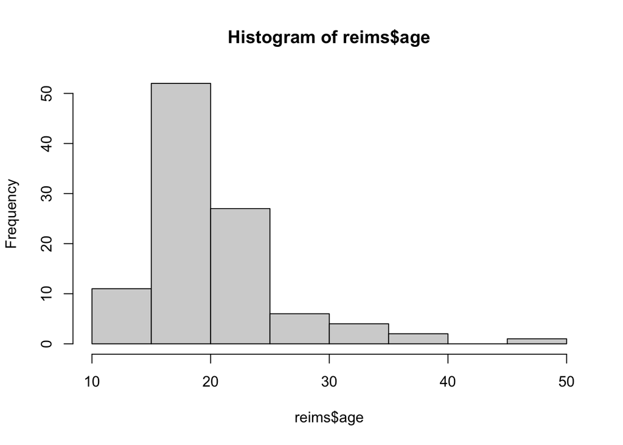

```r
hist(reims$age)
```

```r
table(reims$sex)
```

```
##
##  1  2  3
## 37 65  1
```

```r
table(reims$race)
```

```
##
##  1  2  3  4  5  6  7
## 23  1 12 29  1 30  7
```

```r
# subset data
reims1 <- reims %>%
  select(mathperson1, mathperson2, mathperson3, mathperson4, dislikemathclass, pursuestem, boysbetter) %>%
  rename(m1 = mathperson1,
         m2 = mathperson2,
         m3 = mathperson3,
         m4 = mathperson4,
         dislike = dislikemathclass,
         pursue = pursuestem,
         boys = boysbetter)

head(reims1, n=10)
```

```
## # A tibble: 10 × 7
##       m1    m2    m3    m4 dislike pursue  boys
##    <dbl> <dbl> <dbl> <dbl>   <dbl>  <dbl> <dbl>
##  1     0     0     0     0       0      0     0
##  2     0     0     0     0       1      0     0
##  3     1     1     1     1       0      0     0
##  4     1     1     1     1       1      1     1
##  5     0     0     0     1       0      0     0
##  6     0     0     0     0       1      0     0
##  7     0     0     0     0       0      1     0
##  8     0     0     0     0       0      0     0
##  9     0     0     0     0       1      0     0
## 10     0     0     0     0       1      1     0
```

```r
## add ids and covariates; tell mplus that what we are

# use the reorder function to get hte variables that you want to model in the output.
```

# Models

## Model 1

[interactive chart not shown]

### Model 1 MplusAutomation code

```r
input <- mplusObject(
  TITLE = "REIMS Mathematics Identity Model 1",
  VARIABLE = "categorical = m1 m2 m3 m4;
  usevar = m1-m4;
  classes = c(3);",

  ANALYSIS =
    "estimator = mlr;
    type = mixture;",

  OUTPUT = "tech11 tech14;",

  PLOT = "type = plot3;
    series = m1-m4(*);",

  usevariables = colnames(reims1),
  rdata = reims1)

output <- mplusModeler(input,
                       dataout = here("mplus", "reims1.dat"),
                       modelout = here("mplus", "reims1.inp"),
                       check = T, run = T, hashfilename = F)
```

```
## When hashfilename = FALSE, writeData cannot be 'ifmissing', setting to 'always'
```

```
## The following lines are not empty and do not end in a : or ;.
## 2: REIMS Mathematics Identity Model 1
## 4: FILE = "/Users/nathanalexander/Dropbox/Projects/immerse/reims/mplus/
```

```
## Rerun with parseMplus(add = TRUE) to add semicolons to all lines
```

```
## The file(s)
##  'reims1.dat'
## currently exist(s) and will be overwritten
```

```
## No PROPORTION OF DATA PRESENT sections found within COVARIANCE COVERAGE OF DATA output.
```

Take a look at the item probability plot:

```r
source(here("plot_lca.txt")) # custom function created by Dina to plot our lsa output
model1 <- readModels(here("mplus", "reims1.out")) # read in output
```

```
## No PROPORTION OF DATA PRESENT sections found within COVARIANCE COVERAGE OF DATA output.
```

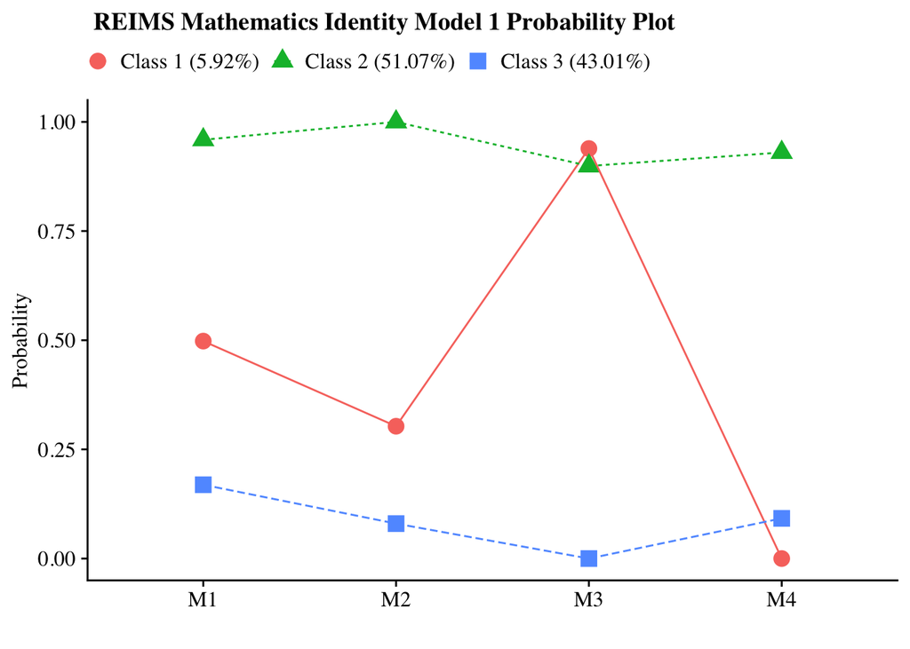

```r
plot_lca(model_name = model1) # there is an error with the non atomic measure columns
```

Show probability plot of data and observe the different classes.

## Model 2

Let’s run a four class model and add three variables.

[interactive chart not shown]

### Model 2 MplusAutomation code

```r
input <- mplusObject(
  TITLE = "REIMS Mathematics Identity Model 2",
  VARIABLE = "categorical = m1 m2 m3 m4 dislike pursue boys;
  usevar = m1-boys;
  classes = c(4);",

  ANALYSIS =
    "estimator = mlr;
    type = mixture;",

  OUTPUT = "tech11 tech14;",

  PLOT = "type = plot3;
    series = m1-boys(*);",

  usevariables = colnames(reims1),
  rdata = reims1)

output <- mplusModeler(input,
                       dataout = here("mplus", "reims1.dat"),
                       modelout = here("mplus", "reims1.inp"),
                       check = T, run = T, hashfilename = F)
```

```
## When hashfilename = FALSE, writeData cannot be 'ifmissing', setting to 'always'
```

```
## The following lines are not empty and do not end in a : or ;.
## 2: REIMS Mathematics Identity Model 2
## 4: FILE = "/Users/nathanalexander/Dropbox/Projects/immerse/reims/mplus/
```

```
## Rerun with parseMplus(add = TRUE) to add semicolons to all lines
```

```
## The file(s)
##  'reims1.dat'
## currently exist(s) and will be overwritten
```

```
## No PROPORTION OF DATA PRESENT sections found within COVARIANCE COVERAGE OF DATA output.
```

Take a look at the item probability plot:

```r
source(here("plot_lca.txt")) # custom function created by Dina to plot our lsa output

model2 <- readModels(here("mplus", "reims1.out")) # read in output
```

```
## No PROPORTION OF DATA PRESENT sections found within COVARIANCE COVERAGE OF DATA output.
```

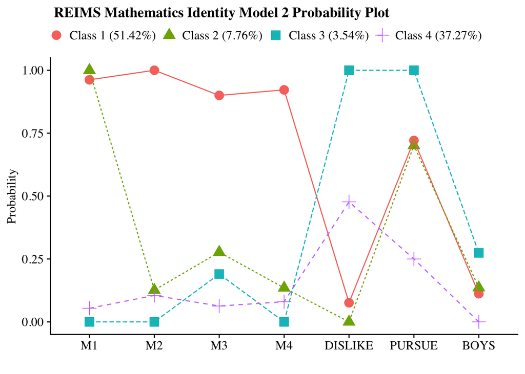

```r
plot_lca(model_name = model2) # there is an error with the non atomic measure columns
```

Show probability plot of data and observe the different classes.

# Enumeration

We use the mplusObject function in the MPlusAutomation package and saves all models run.

```r
# add new libraries
library(cowplot)
library(glue)
```

Proporion of indicators using R:

```r
# set up data to find proportions of binary indicators
df <- reims1 %>%
  pivot_longer(c(m1, m2, m3, m4, dislike, pursue, boys),
  names_to = "Variable")

# create table of variables and counts
t1 <- table(df$Variable, df$value)

# find proportions and round to 3 decimal places
prop <- prop.table(t1, margin =1) %>%
  round(3)

# combine everything to one table
dframe <- data.frame(Variables=rownames(t1), Proportion=prop[,2], Count=t1[,2])

# remove row names
row.names(dframe) <- NULL

# Make it a gt() table
prop_table <- dframe %>%
  gt()
prop_table
```

| Variables | Proportion | Count |
| --- | --- | --- |
| boys | 0.078 | 8 |
| dislike | 0.252 | 26 |
| m1 | 0.592 | 61 |
| m2 | 0.563 | 58 |
| m3 | 0.515 | 53 |
| m4 | 0.515 | 53 |
| pursue | 0.553 | 57 |

```r
# save as a word doc
gtsave(prop_table, here("figures", "prop_table.docx"))
```

Use an enumeration function

```r
lca_4 <- lapply(1:4, function(k) {
  lca_enum <- mplusObject(

    TITLE = glue("{k}-Class"),

    VARIABLE = glue(
      "categorical m1-boys;
      usevar = m1-boys;
      classes = c({k});"),

    ANALYSIS =
      "estimator = mlr;
      type = mixture;
      starts = 500 100;",

    OUTPUT = "tech11 tech14 svalues;",

    usevariables = colnames(reims1),
    rdata = reims1)

  lca_enum_fit <- mplusModeler(lca_enum,
                               dataout = glue(here("reims","enum", "reims1.dat")),
                               modelout = glue(here("reims", "enum", "c{k}_reims1.inp")),
                               check = T, run = T, hashfilename = F)})
```

### table of fit

We want to begin by extracting the data:

```r
output_reims1 <- readModels(here("enum"))
```

```
## No PROPORTION OF DATA PRESENT sections found within COVARIANCE COVERAGE OF DATA output.
## No PROPORTION OF DATA PRESENT sections found within COVARIANCE COVERAGE OF DATA output.
## No PROPORTION OF DATA PRESENT sections found within COVARIANCE COVERAGE OF DATA output.
## No PROPORTION OF DATA PRESENT sections found within COVARIANCE COVERAGE OF DATA output.
```

```r
enum_extract <- LatexSummaryTable(
  output_reims1,
  keepCols = c(
    "Title",
    "Parameters",
    "LL",
    "BIC",
    "aBIC",
    "BLRT_PValue",
    "T11_VLMR_PValue",
    "Observations"
  ),
  sortBy = "Title"
) # select first set of models (Class 1 through 4)

allFit <- enum_extract %>%
  mutate(CAIC = -2 * LL + Parameters * (log(Observations) + 1)) %>%
  mutate(AWE = -2 * LL + 2 * Parameters * (log(Observations) + 1.5)) %>%
  mutate(SIC = -.5 * BIC) %>%
  mutate(expSIC = exp(SIC - max(SIC))) %>%
  mutate(BF = exp(SIC - lead(SIC))) %>%
  mutate(cmPk = expSIC / sum(expSIC)) %>%
  dplyr::select(1:5, 9:10, 6:7, 13, 14) %>%
  arrange(Parameters)
```

Then we create a table:

```r
fit_table <- allFit %>%
  gt() %>%
  tab_header(title = md("**Model Fit Summary Table**")) %>%
  cols_label(
    Title = "Classes",
    Parameters = md("Par"),
    LL = md("*LL*"),
    T11_VLMR_PValue = "VLMR",
    BLRT_PValue = "BLRT",
    BF = md("BF"),
    cmPk = md("*cmPk*")
  ) %>%
  tab_footnote(
    footnote = md(
      "*Note.* Par = Parameters; *LL* = model log likelihood;
BIC = Bayesian information criterion;
aBIC = sample size adjusted BIC; CAIC = consistent Akaike information criterion;
AWE = approximate weight of evidence criterion;
BLRT = bootstrapped likelihood ratio test p-value;
VLMR = Vuong-Lo-Mendell-Rubin adjusted likelihood ratio test p-value;
*cmPk* = approximate correct model probability."
    ),
locations = cells_title()
  ) %>%
  tab_options(column_labels.font.weight = "bold") %>%
  fmt_number(c(3:7),
             decimals = 2) %>%
  sub_missing(1:11,
              missing_text = "--") %>%
  fmt(
    c(8:9, 11),
    fns = function(x)
      ifelse(x < 0.001, "<.001",
             scales::number(x, accuracy = .01))
  ) %>%
  fmt(
    10,
    fns = function (x)
      ifelse(x > 100, ">100",
             scales::number(x, accuracy = .01))
  ) %>%
  tab_style(
    style = list(
      cell_text(weight = "bold")

            ),
    locations = list(cells_body(
     columns = BIC,
     row = BIC == min(BIC[1:6]) # Change this to the number of classes you estimated
    ),
    cells_body(
     columns = aBIC,
     row = aBIC == min(aBIC[1:6])
    ),
    cells_body(
     columns = CAIC,
     row = CAIC == min(CAIC[1:6])
    ),
    cells_body(
     columns = AWE,
     row = AWE == min(AWE[1:6])
    ),
    cells_body(
     columns = cmPk,
     row =  cmPk == max(cmPk[1:6])
     ),
    cells_body(
     columns = BF,
     row =  BF > 10),
    cells_body(
     columns =  T11_VLMR_PValue,
     row =  ifelse(T11_VLMR_PValue < .001 & lead(T11_VLMR_PValue) > .05, T11_VLMR_PValue < .001, NA)),
    cells_body(
     columns =  BLRT_PValue,
     row =  ifelse(BLRT_PValue < .001 & lead(BLRT_PValue) > .05, BLRT_PValue < .001, NA))
  )
)

fit_table
```

**Model Fit Summary Table**<sup>1</sup>

| Classes | Par | *LL* | BIC | aBIC | CAIC | AWE | BLRT | VLMR | BF | *cmPk* |
| --- | --- | --- | --- | --- | --- | --- | --- | --- | --- | --- |
| 1-Class | 7 | −440.03 | 912.50 | 890.38 | 919.50 | 965.94 | – | – | 0.00 | <.001 |
| 2-Class | 15 | −321.24 | 712.00 | 664.61 | 726.99 | 826.52 | <.001 | <.001 | >100 | 1.00 |
| 3-Class | 23 | −314.91 | 736.42 | 663.76 | 759.42 | 912.02 | 1.00 | 0.12 | >100 | <.001 |
| 4-Class | 31 | −312.07 | 767.82 | 669.89 | 798.81 | 1,004.49 | 1.00 | 0.23 | – | <.001 |

<sup>1</sup> *Note.* Par = Parameters; *LL* = model log likelihood; BIC = Bayesian information criterion; aBIC = sample size adjusted BIC; CAIC = consistent Akaike information criterion; AWE = approximate weight of evidence criterion; BLRT = bootstrapped likelihood ratio test p-value; VLMR = Vuong-Lo-Mendell-Rubin adjusted likelihood ratio test p-value; *cmPk* = approximate correct model probability.

save the table:

```r
gtsave(fit_table, here("figures", "fit_table.png"))
```

### Information Criterion Plot

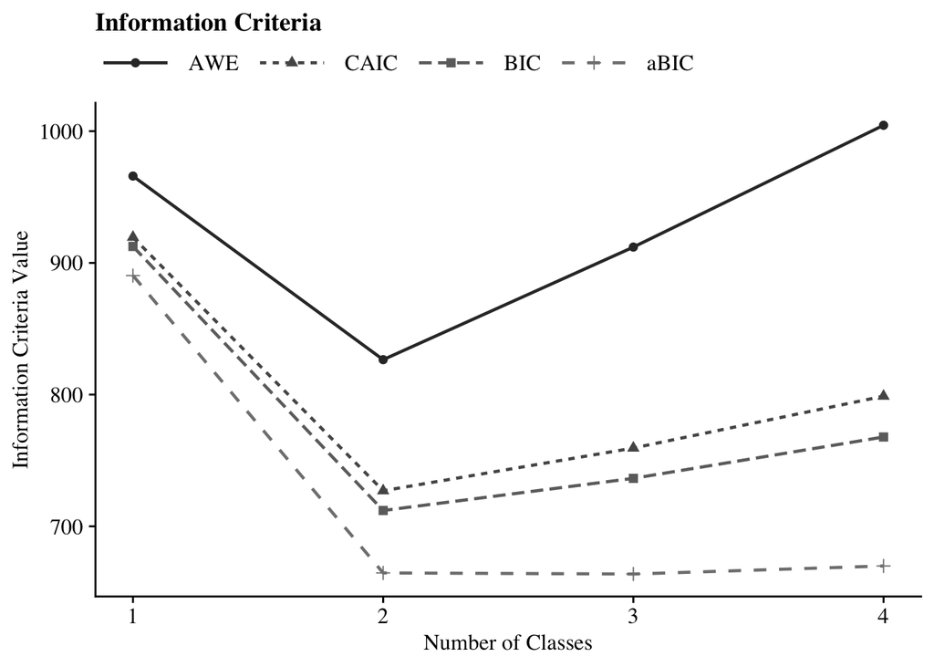

```r
allFit %>%
  dplyr::select(2:7) %>%
  rowid_to_column() %>%
  pivot_longer(`BIC`:`AWE`,
               names_to = "Index",
               values_to = "ic_value") %>%
  mutate(Index = factor(Index,
                        levels = c ("AWE", "CAIC", "BIC", "aBIC"))) %>%
  ggplot(aes(
    x = rowid,
    y = ic_value,
    color = Index,
    shape = Index,
    group = Index,
    lty = Index
  )) +
  geom_point(size = 2.0) + geom_line(size = .8) +
  scale_x_continuous(breaks = 1:nrow(allFit)) +
  scale_colour_grey(end = .5) +
  theme_cowplot() +
  labs(x = "Number of Classes", y = "Information Criteria Value", title = "Information Criteria") +
  theme(
    text = element_text(family = "serif", size = 12),
    legend.text = element_text(family="serif", size=12),
    legend.key.width = unit(3, "line"),
    legend.title = element_blank(),
    legend.position = "top"
  )
```

save the figure:

```r
ggsave(here("figures", "info_criteria.png"), dpi=300, height=5, width=7, units="in")
```

### Compare class solutions

Compare probability plots for $K = 1:4$ class solutions

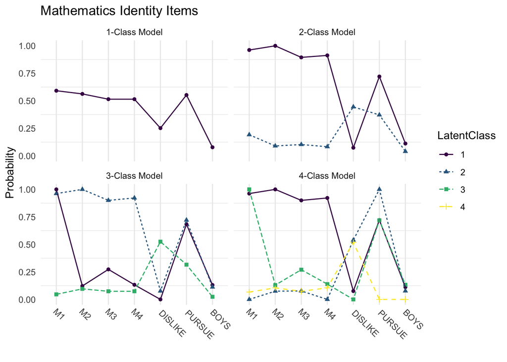

```r
model_results <- data.frame()

for (i in 1:length(output_reims1)) {
  temp <- output_reims1[[i]]$parameters$probability.scale %>%
    mutate(model = paste0(i, "-Class Model"))

  model_results <- rbind(model_results, temp)
}

compare_plot <-
  model_results %>%
  filter(category ==2) %>%
  dplyr::select(est, model, LatentClass, param)

compare_plot$param <- fct_inorder(compare_plot$param)

ggplot(
  compare_plot,
  aes(
    x=param,
    y=est,
    color = LatentClass,
    shape = LatentClass,
    group = LatentClass,
    lty = LatentClass
  )
) +
  geom_point() +
  geom_line() +
  scale_color_viridis_d() +
  facet_wrap(~ model, ncol = 2) +
  labs(title = "Mathematics Identity Items", x = " ", y = "Probability") +
  theme_minimal() +
  theme(panel.grid.major.y = element_blank(),
        axis.text.x = element_text(angle = -45, hjust = -.1))
```

This file is based on resources provided at the Institute of Mixture Modeling for Equity-Oriented Researchers, Scholars, and Educators (2024). IMMERSE In-Person Training Workshop (IES No. 305B220021). Institute of Education Sciences. https://immerse-ucsb.github.io/pre-training